# Machine Learning Final Project

AJD

2023-02-02

## Executive Summary

The goal of this project is to predict the manner in which 6 participants that regularly use fitness collection devices did barbell lifts; correctly or incorrectly. The outcome variable of interest is ‘classe’. We want to use data from accelerometers on the belt, forearm, arm, and dumbell. To determine the best model to predict this variable with, we will try four methods; decision trees, random forests, boosting, and support vector machines. We will also test a combination of all models.

This analysis determine that Random Forests was the best prediction model with 99% accuracy and around a 1% out of sample error.

## Exploratory Data Analysis

```r
read.csv("/Users/difrankaj/Desktop/pml-testing.csv") ->testing
read.csv("/Users/difrankaj/Desktop/pml-training.csv") ->training
library("caret")
library(rattle)
dim(training)
```

```
## [1] 19622   160
```

```r
# THere are 160 variables. There are 20 observations in the test set and 19,622 in the training set.
```

## Data Munging

There are many NA values in the data set- we first want to remove these. Then, we will look for near-zero variance variables and remove those as well.

```r
#Showing NA values
sum(is.na(training))
```

```
## [1] 1287472
```

```r
#Over one million NA values!

#Removing columns that are majorily NA values
condition <- (colSums(is.na(training)) == 0)
training <- training[, condition]
testing <- testing[, condition]
sum(is.na(training))
```

```
## [1] 0
```

```r
#This removed all NAs. We now have 93 variables to work with.

#Removing the first 7 columns that are not relevant predictors- irrelevant to the outcome. Now, 86 variables.
training <- training[, -c(1:7)]
testing <- testing[, -c(1:7)]
```

Removing near-zero variance variables

```r
near <- nearZeroVar(training)
training <- training[, -near]
testing <- testing[, -near]
#We now have 53 variables.
```

In order to perform cross validation, we will subset the training dataset into training and an addition validation dataset.

```r
#Create data partition using the caret package
inTrain <- createDataPartition(y = training$classe, p = 0.7, list = FALSE)
train <- training[inTrain, ]
validation <- training[-inTrain, ]
```

## Creating and Testing Models

Control for cross validation

```r
control <- trainControl(method="cv", number=5, verboseIter=FALSE)
```

#### Model 1: Decision Trees

Basic Idea: Split variables into groups based on a decision split, evaluate the homogeneity within each group, split again if necessary.

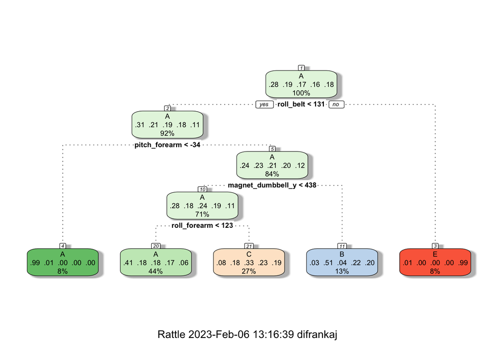

```r
dectrees<- train(classe~., method= "rpart", trControl = control, data=train)
#Visual:
fancyRpartPlot(dectrees$finalModel)
```

Testing prediction

```r
DTpred<- predict(dectrees, validation)
confusionMatrix(DTpred, factor(validation$classe))
```

```
## Confusion Matrix and Statistics
##
##           Reference
## Prediction    A    B    C    D    E
##          A 1521  474  477  426  153
##          B   31  383   32  188  137
##          C  119  282  517  350  267
##          D    0    0    0    0    0
##          E    3    0    0    0  525
##
## Overall Statistics
##
##                Accuracy : 0.5006
##                  95% CI : (0.4877, 0.5135)
##     No Information Rate : 0.2845
##     P-Value [Acc > NIR] : < 2.2e-16
##
##                   Kappa : 0.3474
##
##  Mcnemar's Test P-Value : NA
##
## Statistics by Class:
##
##                      Class: A Class: B Class: C Class: D Class: E
## Sensitivity            0.9086  0.33626  0.50390   0.0000  0.48521
## Specificity            0.6367  0.91825  0.79049   1.0000  0.99938
## Pos Pred Value         0.4985  0.49676  0.33681      NaN  0.99432
## Neg Pred Value         0.9460  0.85217  0.88299   0.8362  0.89602
## Prevalence             0.2845  0.19354  0.17434   0.1638  0.18386
## Detection Rate         0.2585  0.06508  0.08785   0.0000  0.08921
## Detection Prevalence   0.5184  0.13101  0.26083   0.0000  0.08972
## Balanced Accuracy      0.7726  0.62725  0.64720   0.5000  0.74229
```

##### Model 2: Random Forests

Basic Idea: Take bootsrapped sample, at each tree split build boostrapped variables in each sample, hence growing multiple trees, then vote/average these trees to create best prediction model.

```r
rf<- train(classe~., method="rf", trControl= control, data=train)
```

Testing prediction

```r
RFpred<- predict(rf, validation)
confusionMatrix(RFpred, factor(validation$classe))
```

```
## Confusion Matrix and Statistics
##
##           Reference
## Prediction    A    B    C    D    E
##          A 1671    9    0    0    0
##          B    2 1129    3    0    0
##          C    0    1 1022   17    3
##          D    0    0    1  947    3
##          E    1    0    0    0 1076
##
## Overall Statistics
##
##                Accuracy : 0.9932
##                  95% CI : (0.9908, 0.9951)
##     No Information Rate : 0.2845
##     P-Value [Acc > NIR] : < 2.2e-16
##
##                   Kappa : 0.9914
##
##  Mcnemar's Test P-Value : NA
##
## Statistics by Class:
##
##                      Class: A Class: B Class: C Class: D Class: E
## Sensitivity            0.9982   0.9912   0.9961   0.9824   0.9945
## Specificity            0.9979   0.9989   0.9957   0.9992   0.9998
## Pos Pred Value         0.9946   0.9956   0.9799   0.9958   0.9991
## Neg Pred Value         0.9993   0.9979   0.9992   0.9966   0.9988
## Prevalence             0.2845   0.1935   0.1743   0.1638   0.1839
## Detection Rate         0.2839   0.1918   0.1737   0.1609   0.1828
## Detection Prevalence   0.2855   0.1927   0.1772   0.1616   0.1830
## Balanced Accuracy      0.9980   0.9951   0.9959   0.9908   0.9971
```

This model is approximately 99% accurate! The out of sample error is then around 0.01.

#### Model 3: Gradient Boosted Trees

Basic Idea: Resample the data several times, recalculated predictions based on the previous sample, and after the resampling, average/majority vote the results for a final prediction model.

Testing prediction

```r
boostpred<- predict(boost, validation)
confusionMatrix(boostpred, factor(validation$classe))
```

[output not shown]

```
## Confusion Matrix and Statistics
##
##           Reference
## Prediction    A    B    C    D    E
##          A 1644   50    0    0    0
##          B   20 1063   23    1    6
##          C    4   22  986   22    7
##          D    5    3   16  929   13
##          E    1    1    1   12 1056
##
## Overall Statistics
##
##                Accuracy : 0.9648
##                  95% CI : (0.9598, 0.9694)
##     No Information Rate : 0.2845
##     P-Value [Acc > NIR] : < 2.2e-16
##
##                   Kappa : 0.9555
##
##  Mcnemar's Test P-Value : 0.000279
##
## Statistics by Class:
##
##                      Class: A Class: B Class: C Class: D Class: E
## Sensitivity            0.9821   0.9333   0.9610   0.9637   0.9760
## Specificity            0.9881   0.9895   0.9887   0.9925   0.9969
## Pos Pred Value         0.9705   0.9551   0.9472   0.9617   0.9860
## Neg Pred Value         0.9928   0.9841   0.9917   0.9929   0.9946
## Prevalence             0.2845   0.1935   0.1743   0.1638   0.1839
## Detection Rate         0.2794   0.1806   0.1675   0.1579   0.1794
## Detection Prevalence   0.2879   0.1891   0.1769   0.1641   0.1820
## Balanced Accuracy      0.9851   0.9614   0.9748   0.9781   0.9864
```

This model is approximately 96% accurate!The out of sample error is then around 0.04.

#### Model 4: Support Vector Machine

Basic Idea: Maximize the margin of the classifier by use of support vectors; mapping data to a high-dimensional feature space so that data points can be categorized.

```r
svm<- train(classe~., method="svmLinear", trControl=control, data=train)
```

Testing prediction

```r
svmpred<- predict(svm, validation)
confusionMatrix(svmpred, factor(validation$classe))
```

```
## Confusion Matrix and Statistics
##
##           Reference
## Prediction    A    B    C    D    E
##          A 1525  145   79   60   62
##          B   40  821  100   35  132
##          C   52   68  784  107   59
##          D   47   19   27  717   50
##          E   10   86   36   45  779
##
## Overall Statistics
##
##                Accuracy : 0.7861
##                  95% CI : (0.7754, 0.7965)
##     No Information Rate : 0.2845
##     P-Value [Acc > NIR] : < 2.2e-16
##
##                   Kappa : 0.7282
##
##  Mcnemar's Test P-Value : < 2.2e-16
##
## Statistics by Class:
##
##                      Class: A Class: B Class: C Class: D Class: E
## Sensitivity            0.9110   0.7208   0.7641   0.7438   0.7200
## Specificity            0.9178   0.9353   0.9411   0.9709   0.9631
## Pos Pred Value         0.8151   0.7278   0.7327   0.8337   0.8149
## Neg Pred Value         0.9629   0.9332   0.9497   0.9508   0.9385
## Prevalence             0.2845   0.1935   0.1743   0.1638   0.1839
## Detection Rate         0.2591   0.1395   0.1332   0.1218   0.1324
## Detection Prevalence   0.3179   0.1917   0.1818   0.1461   0.1624
## Balanced Accuracy      0.9144   0.8281   0.8526   0.8574   0.8416
```

This model is approximately 79% accurate. The out of sample error is then around 0.21.

#### Model 5: Combining predictors by averaging

Method: Model stacking

```r
#First, combine the predictions from models 2-4 into one dataframe
combdf<- data.frame(RFpred, boostpred, svmpred, classe=validation$classe)
combFit<- train(classe~., method= "gam", data=combdf)
#Checking accuracy:
combpred<- predict(combFit, validation)
confusionMatrix(combpred, factor(validation$classe))
```

```
## Confusion Matrix and Statistics
##
##           Reference
## Prediction    A    B    C    D    E
##          A 1671    9    0    0    0
##          B    3 1130 1026  964 1082
##          C    0    0    0    0    0
##          D    0    0    0    0    0
##          E    0    0    0    0    0
##
## Overall Statistics
##
##                Accuracy : 0.476
##                  95% CI : (0.4631, 0.4888)
##     No Information Rate : 0.2845
##     P-Value [Acc > NIR] : < 2.2e-16
##
##                   Kappa : 0.3286
##
##  Mcnemar's Test P-Value : NA
##
## Statistics by Class:
##
##                      Class: A Class: B Class: C Class: D Class: E
## Sensitivity            0.9982   0.9921   0.0000   0.0000   0.0000
## Specificity            0.9979   0.3521   1.0000   1.0000   1.0000
## Pos Pred Value         0.9946   0.2687      NaN      NaN      NaN
## Neg Pred Value         0.9993   0.9946   0.8257   0.8362   0.8161
## Prevalence             0.2845   0.1935   0.1743   0.1638   0.1839
## Detection Rate         0.2839   0.1920   0.0000   0.0000   0.0000
## Detection Prevalence   0.2855   0.7145   0.0000   0.0000   0.0000
## Balanced Accuracy      0.9980   0.6721   0.5000   0.5000   0.5000
```

This model is extremely innacurate at approximately 48%.

The best model is random forests, with 99% accuracy. Now we will predict the classe (5 levels) on the test set.

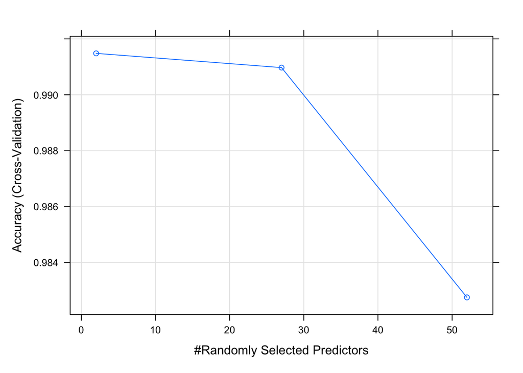

```r
plot(rf)
```

```r
testpred<- predict(rf, testing)
testpred
```

```
##  [1] B A B A A E D B A A B C B A E E A B B B
## Levels: A B C D E
```